# Implementando modelos bayesianos

Fellipe Gomes

12 de dezembro de 2017

# Inferência bayesiana

Quando estamos falando de Inferência nosso objetivo normalmente é tentar verificar alguma informação sobre uma quantidade desconhecida.

Para isso devemos utilizamos **toda** informação disponível, seja ela **objetiva** ou **subjetiva** (isto é, vinda de umam amostra ou de algum conhecimento préveo ou intuitivo)

Segundo o ponto de vista Bayesiano essa informação subjetiva também será incorporada na análise graças ao [teorema de bayes](https://pt.wikipedia.org/wiki/Teorema_de_Bayes).

Como no ponto de vista Bayesiano atribuímos aleatoriedade ao parâmetro, nossa “crença” será representada por uma distribuição de probabilidade (ou modelo probabilístico)

*Teorema de bayes*:
$$p(\theta|x)=\frac{p(x,\theta)}{p(x)}=\frac{p(x|\theta)p(\theta)}{p(x)}$$

onde:

- $p(x|\theta)$: função de verossimilhança (modelo)
- $p(\theta)$: distribuição a priori
- $p(x)$: distribuição marginal de $x$.

A estimação muitas vezes envolve o cálculo de integrais nada simples analiticamente porém, alguns algorítimos como o amostrador de Gibbs pode relizar aproximações muito relevantes.

# Modelo linear bayesiano

Para entender como funciona o modelo bayesiano, primeiramente vamos começar com algo bem simples, suponha:

$$Y_i \sim N(\mu_i,\tau)$$
onde $\mu$ é definido como $\mu_i= X \mathbf{\beta}$.

Considere também a priori:

$$\beta \sim N(0,\tau_{\beta})$$

onde $\tau$ é conhecido.

Nem sempre é uma tarefa simples determinar a distribuição posteri de um modelo bayesiano e é neste ponto que o pacote `jags`será bastante útil (existem outras alternativas como o [WinBugs](https://cran.r-project.org/package=R2WinBUGS), [OpenBugs](https://cran.r-project.org/package=R2OpenBUGS), [Stan](https://cran.r-project.org/web/packages/rstan/index.html), mas aqui resolvi trazer apenas o jags por possuir vantagens bem interessantes.)

# Jags

O pacote [`R2jags`](https://cran.r-project.org/package=R2jags) é exatamente o que seu nome significa: “*Just Another Gibbs Sampler*”. Possui as mesmas funcionalidades do nosso querido [OpenBugs](https://cran.r-project.org/package=R2OpenBUGS) possibilitando também que seja utilizado inteiramente dentro do ambiente R.

Assim como o OpenBugs, ele também trabalha chamando o software oficial que precisa ser baixado no site.

Para começar a utilizar basta baixar o pacote e acessá-lo na biblioteca:

```r
library(R2jags)
```

# Declarando o modelo

A base de dados que será utilizada para ajustar o modelo será a base nativa do R chamada `trees`:

```r
X<-trees[,1:2] #Matriz de variáveis explanatórias
Y<- trees[,3]  #Vetor da variável resposta
p <- ncol(X)   #p é o número de parâmetros do modelo (nesse caso é o número de colunas)
n <- nrow(X)   #n é o número de observações do modelo
```

O modelo deve estar declarado e salvo em um arquivo `.txt` (ou mesmo um outro arquivo `.r`) da seguinte maneira:

```r
### Declarando o modelo Bayesiano
sink("linreg.txt")
cat("
    model {

    # Prioris
    for(j in 1:p)
    {
    beta[j] ~ dnorm(mu.beta, tau.beta)
    }
    sigma ~ dunif(0, 100)
    tau <- 1/ (sigma * sigma)

    # Verossimilhança
    for (i in 1:n) {
    y[i] ~ dnorm(mu[i], tau)
    mu[i] <- inprod(X[i,], beta)
    }

    }
    ",fill=TRUE)
sink()
```

Uma vez que o modelo esta declarado, é a hora de nomear os parametros da função que fará o ajuste do modelo

```r
#Parametros da Priori
mu.beta <- 0
tau.beta <- 0.001

#Set Working Directory
wd <- getwd()

# Junte os dados em uma lista
win.data <- list(X=X,y=Y,p=p,n=n,mu.beta=mu.beta,tau.beta=tau.beta)

# Função de inicialização
inits <- function(){ list(beta=rnorm(p), sigma = rlnorm(1))}

# Os parametros que desejamos estimar
params <- c("beta","sigma","tau")

# Caracteristicas do MCMC
n.burnin <- 500                    #Número de iterações que serão descartadas
n.thin <- 10                       #para economizar memória e tempo de computação se n.iter for grande
n.post <- 5000
n.chains <- 3                      #Número de cadeias
n.iter <- n.burnin + n.thin*n.post #Número de iterações
```

# Implementando o modelo

Após ter em mãos todos esses resultados, já podemos ajustar o modelo com o comando `jags()`, veja:

```r
bayes.mod.fit <-jags(data = win.data,
                     inits = inits,
                     parameters = params,
                     model.file = "linreg.txt",  # O arquivo "linreg.txt" deve estar no mesmo diretório
                     n.iter = n.iter,
                     n.thin=n.thin,
                     n.burnin=n.burnin,
                     n.chains=n.chains,
                     working.directory=wd,DIC = T)
```

```
## module glm loaded
```

```r
print(bayes.mod.fit, dig = 3)
```

```
## Inference for Bugs model at "linreg.txt", fit using jags,
##  3 chains, each with 50500 iterations (first 500 discarded), n.thin = 10
##  n.sims = 15000 iterations saved
##          mu.vect sd.vect    2.5%     25%     50%     75%   97.5%  Rhat
## beta[1]    5.043   0.433   4.173   4.762   5.043   5.328   5.902 1.002
## beta[2]   -0.477   0.077  -0.628  -0.528  -0.477  -0.427  -0.323 1.002
## sigma      6.440   0.901   4.950   5.808   6.348   6.965   8.517 1.002
## tau        0.025   0.007   0.014   0.021   0.025   0.030   0.041 1.002
## deviance 201.933   2.677 198.875 199.989 201.264 203.145 208.934 1.001
##          n.eff
## beta[1]   2200
## beta[2]   2200
## sigma     3000
## tau       3000
## deviance 13000
##
## For each parameter, n.eff is a crude measure of effective sample size,
## and Rhat is the potential scale reduction factor (at convergence, Rhat=1).
##
## DIC info (using the rule, pD = var(deviance)/2)
## pD = 3.6 and DIC = 205.5
## DIC is an estimate of expected predictive error (lower deviance is better).
```

# Diagnósticos do modelo com `mcmcplots`

Para o diagnóstico do modelo podemos utilizar o pacote `mcmcplots` que fornece de maneira bem agradável os resultados gerados pelo amostrador, primeiramente vamos carregar o pacote:

```r
suppressMessages(library(mcmcplots))
```

Em seguida precisar informar para o `R` que o resultado do algorítimo se trata de um objeto mcmc, portanto:

```r
bayes.mod.fit.mcmc <- as.mcmc(bayes.mod.fit)
summary(bayes.mod.fit.mcmc)
```

```
##
## Iterations = 1:49991
## Thinning interval = 10
## Number of chains = 3
## Sample size per chain = 5000
##
## 1. Empirical mean and standard deviation for each variable,
##    plus standard error of the mean:
##
##               Mean       SD  Naive SE Time-series SE
## beta[1]    5.04272 0.433233 3.537e-03      3.510e-03
## beta[2]   -0.47709 0.077251 6.307e-04      6.245e-04
## deviance 201.93324 2.677099 2.186e-02      2.186e-02
## sigma      6.44031 0.901409 7.360e-03      7.256e-03
## tau        0.02548 0.006855 5.597e-05      5.511e-05
##
## 2. Quantiles for each variable:
##
##               2.5%       25%       50%       75%     97.5%
## beta[1]    4.17254   4.76160   5.04267   5.32810   5.90213
## beta[2]   -0.62804  -0.52821  -0.47657  -0.42692  -0.32343
## deviance 198.87472 199.98937 201.26354 203.14537 208.93449
## sigma      4.95036   5.80762   6.34830   6.96496   8.51742
## tau        0.01378   0.02061   0.02481   0.02965   0.04081
```

O pacote nos fornece alguns tipos de gráficos para diagnóstico

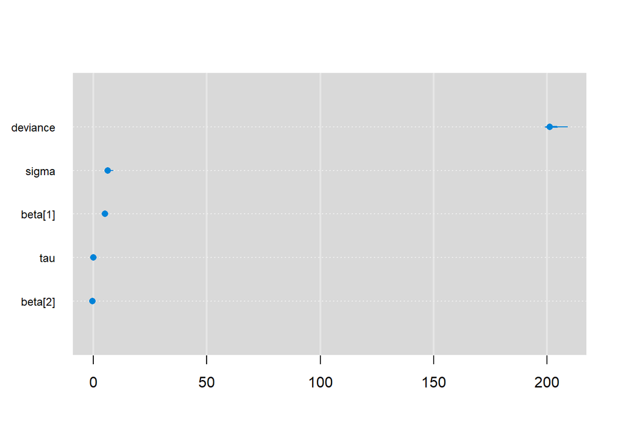

```r
caterplot(bayes.mod.fit.mcmc)                #Observando todas as estimativas
```

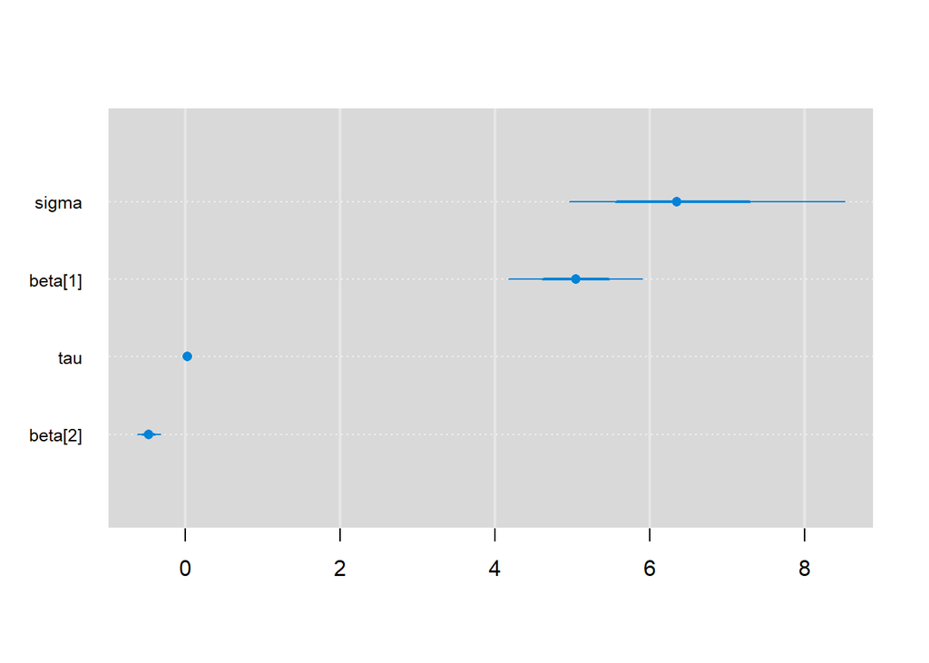

```r
caterplot(bayes.mod.fit.mcmc,parms = params) #Observando as estimativas de todos os parâmetros sem o desvio
```

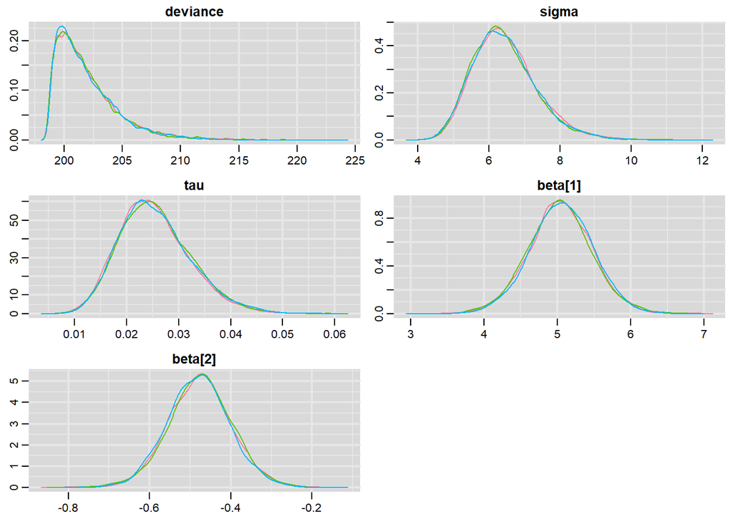

```r
denplot(bayes.mod.fit.mcmc)                  #Densidade das estimativas de cada cadeia
```

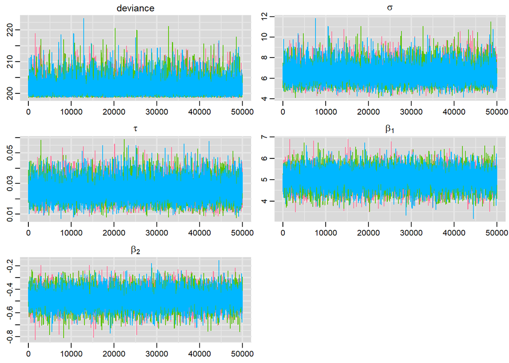

```r
traplot(bayes.mod.fit.mcmc,greek = T)        #Avaliando a convergência
```

Para diagnósticos rápidos, pode produzir arquivos html com traço, densidade e autocorrelação.

O comando traça tudo em uma página e os arquivos serão exibidos em seu navegador de internet padrão.

```r
#mcmcplot(bayes.mod.fit.mcmc)
```

Vai retornar algo como:

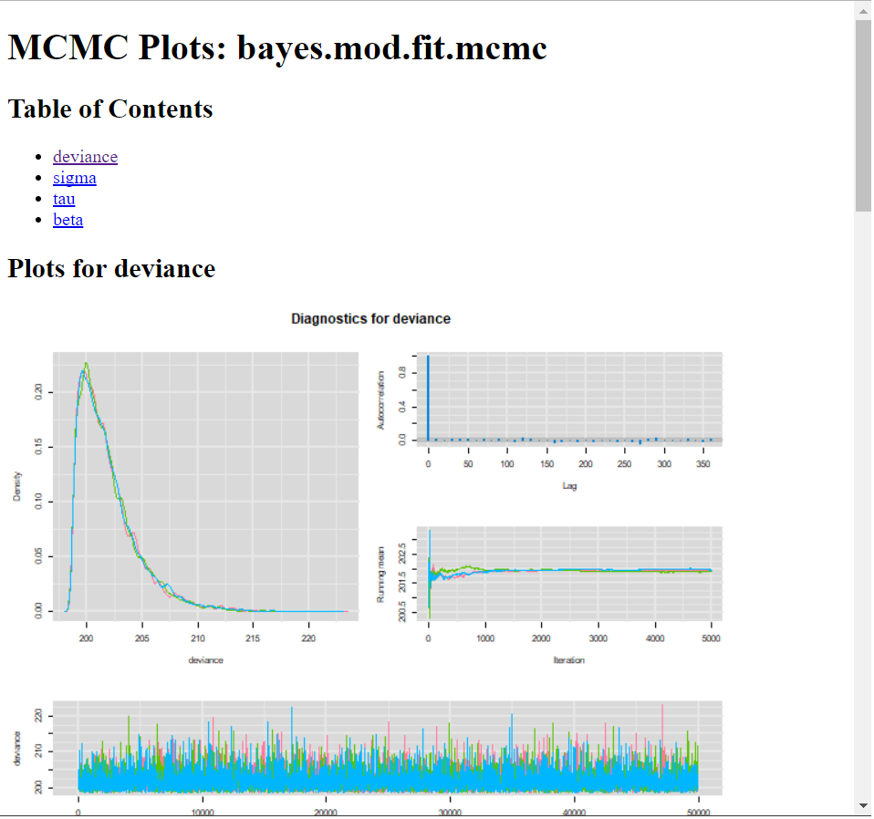

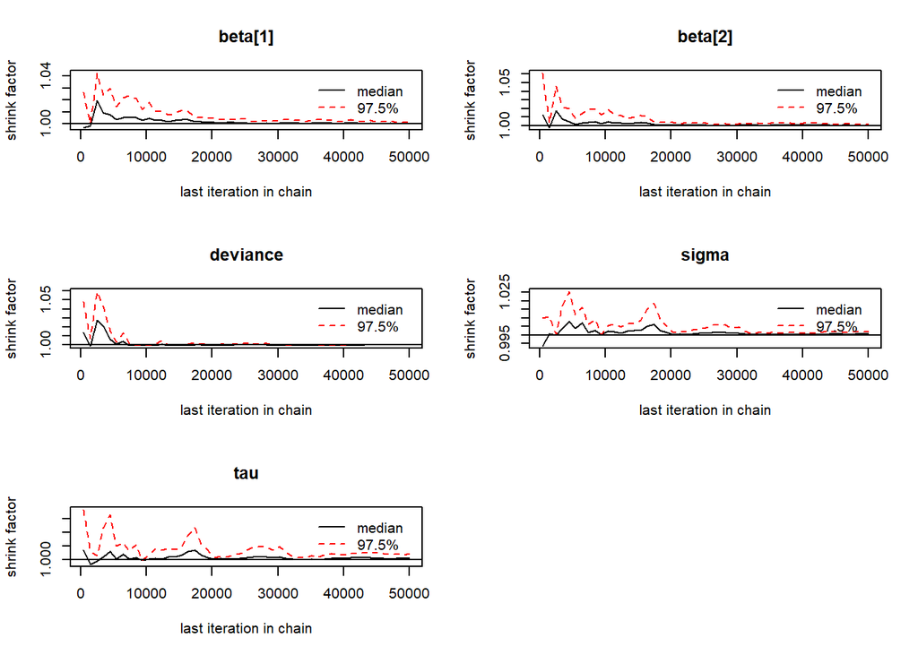

```r
#Diagnosticos estatísticos do modelo:

#Mais diagnosticos:
gelman.plot(bayes.mod.fit.mcmc)
```

```r
geweke.diag(bayes.mod.fit.mcmc)
```

```
## [[1]]
##
## Fraction in 1st window = 0.1
## Fraction in 2nd window = 0.5
##
##   beta[1]   beta[2]  deviance     sigma       tau
##  1.532825 -1.600152  0.813616  0.072612 -0.002362
##
##
## [[2]]
##
## Fraction in 1st window = 0.1
## Fraction in 2nd window = 0.5
##
##  beta[1]  beta[2] deviance    sigma      tau
## -2.10650  1.47614 -0.08896 -1.52494  1.20629
##
##
## [[3]]
##
## Fraction in 1st window = 0.1
## Fraction in 2nd window = 0.5
##
##  beta[1]  beta[2] deviance    sigma      tau
##   0.2195  -0.5585  -0.7705   0.6684  -0.8101
```

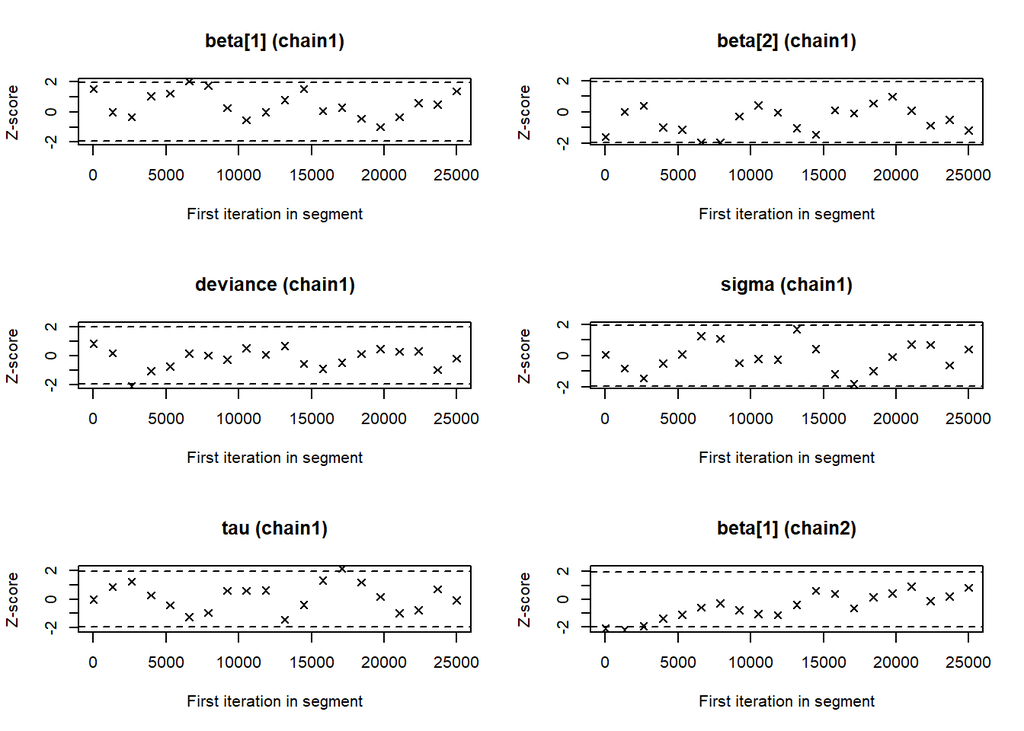

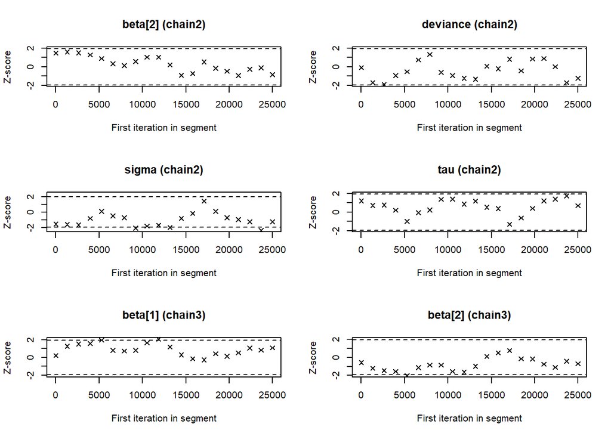

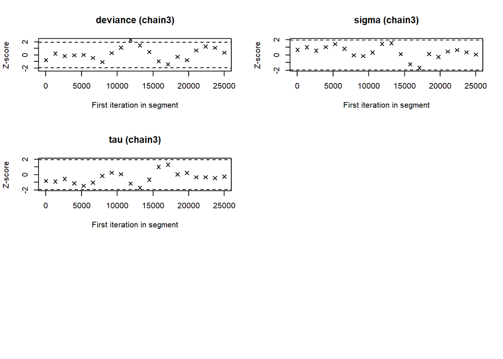

```r
geweke.plot(bayes.mod.fit.mcmc)
```

```r
raftery.diag(bayes.mod.fit.mcmc)
```

```
## [[1]]
##
## Quantile (q) = 0.025
## Accuracy (r) = +/- 0.005
## Probability (s) = 0.95
##
##           Burn-in  Total Lower bound  Dependence
##           (M)      (N)   (Nmin)       factor (I)
##  beta[1]  20       38030 3746         10.20
##  beta[2]  20       38660 3746         10.30
##  deviance 20       37410 3746          9.99
##  sigma    20       38030 3746         10.20
##  tau      20       39300 3746         10.50
##
##
## [[2]]
##
## Quantile (q) = 0.025
## Accuracy (r) = +/- 0.005
## Probability (s) = 0.95
##
##           Burn-in  Total Lower bound  Dependence
##           (M)      (N)   (Nmin)       factor (I)
##  beta[1]  20       36800 3746         9.82
##  beta[2]  20       36200 3746         9.66
##  deviance 20       37410 3746         9.99
##  sigma    20       37410 3746         9.99
##  tau      20       36200 3746         9.66
##
##
## [[3]]
##
## Quantile (q) = 0.025
## Accuracy (r) = +/- 0.005
## Probability (s) = 0.95
##
##           Burn-in  Total Lower bound  Dependence
##           (M)      (N)   (Nmin)       factor (I)
##  beta[1]  20       38030 3746         10.20
##  beta[2]  20       39950 3746         10.70
##  deviance 20       36200 3746          9.66
##  sigma    20       35610 3746          9.51
##  tau      30       40620 3746         10.80
```

```r
heidel.diag(bayes.mod.fit.mcmc)
```

```
## [[1]]
##
##          Stationarity start     p-value
##          test         iteration
## beta[1]  passed       1         0.145
## beta[2]  passed       1         0.174
## deviance passed       1         0.966
## sigma    passed       1         0.974
## tau      passed       1         0.952
##
##          Halfwidth Mean     Halfwidth
##          test
## beta[1]  passed      5.0390 0.012050
## beta[2]  passed     -0.4761 0.002151
## deviance passed    201.9789 0.075150
## sigma    passed      6.4705 0.025030
## tau      passed      0.0252 0.000188
##
## [[2]]
##
##          Stationarity start     p-value
##          test         iteration
## beta[1]  passed       1         0.073
## beta[2]  passed       1         0.178
## deviance passed       1         0.962
## sigma    passed       1         0.167
## tau      passed       1         0.503
##
##          Halfwidth Mean     Halfwidth
##          test
## beta[1]  passed      5.0293 0.011911
## beta[2]  passed     -0.4748 0.002103
## deviance passed    201.9171 0.074084
## sigma    passed      6.4165 0.024413
## tau      passed      0.0257 0.000186
##
## [[3]]
##
##          Stationarity start     p-value
##          test         iteration
## beta[1]  passed       1         0.139
## beta[2]  passed       1         0.150
## deviance passed       1         0.795
## sigma    passed       1         0.294
## tau      passed       1         0.283
##
##          Halfwidth Mean     Halfwidth
##          test
## beta[1]  passed      5.0598 0.011783
## beta[2]  passed     -0.4803 0.002106
## deviance passed    201.9037 0.073370
## sigma    passed      6.4339 0.024454
## tau      passed      0.0255 0.000188
```

```r
#Diagnostico de convergencia rapida: superdiag
#Uma função muito conveniente para analisar representações numéricas de diagnósticos em uma varredura é o pacote de superdiag (Tsai, Gill e Rapkin, 2012).
library(superdiag)
superdiag(bayes.mod.fit.mcmc, burnin = 100)
```

```
## Number of chains = 3
## Number of iterations = 5000 per chain before discarding the burn-in period
## The burn-in period = 100 per chain
## Sample size in total = 14700
##
## ********** The Geweke diagnostic: **********
## Z-scores:
##                        chain1    chain 2     chain 3
## beta[1]           -0.04392195 -0.2043198  1.26069666
## beta[2]            0.05345748 -0.1042316 -1.31616703
## deviance           0.56880093 -0.1699937 -0.06389295
## sigma             -0.70259346 -1.1798697  0.75527605
## tau                0.69112695  0.4615593 -0.73330964
## Window From Start  0.10000000  0.5986500  0.46607000
## Window From Stop   0.50000000  0.2188900  0.52024000
##
## ********** The Gelman-Rubin diagnostic: **********
## Potential scale reduction factors:
##
##          Point est. Upper C.I.
## beta[1]           1          1
## beta[2]           1          1
## deviance          1          1
## sigma             1          1
## tau               1          1
##
## Multivariate psrf
##
## 1
##
## ********** The Heidelberger-Welch diagnostic: **********
##
## Chain 1, epsilon=0.1, alpha=0.05
##          Stationarity start     p-value
##          test         iteration
## beta[1]  passed       1         0.373
## beta[2]  passed       1         0.428
## deviance passed       1         0.961
## sigma    passed       1         0.962
## tau      passed       1         0.915
```

[output cut: 57 more lines]

```
##
##
## Chain 2, converge.eps = 5e-04
## Quantile (q) = 0.1
## Accuracy (r) = +/- 0.0025
## Probability (s) = 0.95
##
## You need a sample size of at least 55318 with these values of q, r and s
##
## Chain 3, converge.eps = 0.001
## Quantile (q) = 0.05
## Accuracy (r) = +/- 0.0025
## Probability (s) = 0.999
##
## You need a sample size of at least 82290 with these values of q, r and s
```

```r
#Atualizando o modelo, se necessário - por exemplo, se não houver convergência ou pouca convergencia:
bayes.mod.fit.upd <- update(bayes.mod.fit, n.iter=1000)
bayes.mod.fit.upd <- autojags(bayes.mod.fit)
```